# Final

Zachary Palmore

5/20/2021

```r
library(tidyverse)
library(kableExtra)
```

## Problem 1

Using R, generate a random variable X that has 10,000 random uniform numbers from 1 to N, where N can be any number of your choosing greater than or equal to 6. Then generate a random variable Y that has 10,000 random normal numbers with a mean of $\mu=\sigma=(N+1)/2.$

```r
set.seed(41)
N <- 41 # Random number greater than or equal to 6
n <- 10000 # Quantity of random normal numbers to generate
sigma <- (N + 1)/2 # Sigma
mu <- sigma # Mu = Sigma
# Generate random number
df <- data.frame(X = runif(n, min = 1, max = N),
                 Y = rnorm(n, mean = mu, sd = sigma))
# Display random numbers
head(df, 10)
```

```
##            X         Y
## 1   9.539620 21.708869
## 2  39.849134 17.692613
## 3  24.127480 24.785695
## 4   6.683199 21.316268
## 5  34.670271 -8.210459
## 6  39.481321 14.583845
## 7  37.050824 -1.709704
## 8  21.876923 36.841523
## 9  33.698672 30.865059
## 10 27.731654 41.466029
```

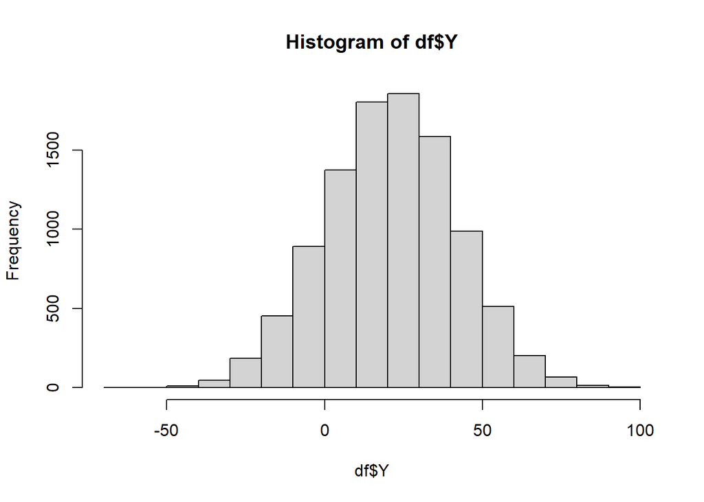

```r
hist(df$Y)
```

Probability. Calculate as a minimum the below probabilities a through c. Assume the small letter “x” is estimated as the median of the X variable, and the small letter “y” is estimated as the 1st quartile of the Y variable. Interpret the meaning of all probabilities.

$$A. \ P(X>x | X>y) \hspace{8pt} B. \ P(X>x, Y>y) \hspace{8pt} C. P(X<x | X>y)$$

If we assume the small letter $x$ is estimated as the median of X variable, and the small letter $y$ is estimated as the 1st quartile of the Y variable then we have the following values of $x$ and $y$ and can calculate the minimum as such:

```r
x = median(df$X) # median of X
y = quantile(df$Y, 0.25) # 1st quartile of Y
# A. P(X>x | X>y)
PXxXy <- df %>%
  filter(X>x, X>y) %>%
  nrow() / n
PXy <- df %>%
  filter(X>y) %>%
  nrow() / n
A <- signif((PXxXy / PXy), 3)
# B. P(X>x, Y>y)
PXxXy <- df %>%
  filter(X>x, Y>y) %>%
  nrow() / n
B <- signif(PXxXy, 3)
# C. P(X<x | X>y)
PXxXy <- df %>%
  filter(X < x,
         X > y) %>%
  nrow() / n
PXy <- df %>%
  filter(X > y) %>%
  nrow() / n
C <- PXxXy/PXy
print(paste("A.:",A,"B.:",B,"C.:",C))
```

```
## [1] "A.: 0.583 B.: 0.375 C.: 0.417045587035094"
```

Investigate whether $P(X>x and Y>y)=P(X>x)P(Y>y)$ by building a table and evaluating the marginal and joint probabilities.

```r
# Joint P
JAB <- df %>%
  mutate(A = ifelse(X > x, "X > x", "X < x")) %>%
  mutate(B = ifelse(Y > y, " Y > y", " Y < y")) %>%
  group_by(A, B) %>%
  summarise(total = n()) %>%
  mutate(P = total / n)
# Marginal P
MA <- JAB %>%
  ungroup() %>%
  group_by(A) %>%
  summarise(sum = sum(total), P = sum(P))
MB <- JAB %>%
  ungroup() %>%
  group_by(B) %>%
  summarise(sum = sum(total), P = sum(P))
# build a table
tbl <- bind_rows(JAB, MA, MB) %>%
  select(-total) %>%
  spread(A, P)
colnames(tbl) <- c("Condition", "sum", "X<x", "X>x", "Total")
kable(tbl)
```

| Condition | sum | X<x | X>x | Total |
| --- | --- | --- | --- | --- |
| Y < y | 2500 | NA | NA | 0.25 |
| Y < y | NA | 0.125 | 0.125 | NA |
| Y > y | 7500 | NA | NA | 0.75 |
| Y > y | NA | 0.375 | 0.375 | NA |
| NA | 5000 | 0.500 | 0.500 | NA |

They are the approximately the same. Close enough that we can state $P(X>x and Y>y)=P(X>x)P(Y>y)$.

Check to see if independence holds by using Fisher’s Exact Test and the Chi Square Test. What is the difference between the two? Which is most appropriate?

```r
xy <- table(df$X>x, df$Y>y)
chisq.test(xy, correct=T)
```

```
##
##  Pearson's Chi-squared test
##
## data:  xy
## X-squared = 0, df = 1, p-value = 1
```

```r
fisher.test(xy,simulate.p.value=T)
```

```
##
##  Fisher's Exact Test for Count Data
##
## data:  xy
## p-value = 1
## alternative hypothesis: true odds ratio is not equal to 1
## 95 percent confidence interval:
##  0.9124854 1.0959080
## sample estimates:
## odds ratio
##          1
```

Chi-squared is most appropriate due to sample size and independence holds with large p-value.

## Problem 2

You are to register for Kaggle.com (free) and compete in the House Prices: Advanced Regression Techniques competition. https://www.kaggle.com/c/house-prices-advanced-regression-techniques . I want you to do the following.

$^{1}$5 points. Descriptive and Inferential Statistics. Provide univariate descriptive statistics and appropriate plots for the training data set. Provide a scatterplot matrix for at least two of the independent variables and the dependent variable. Derive a correlation matrix for any three quantitative variables in the dataset. Test the hypotheses that the correlations between each pairwise set of variables is 0 and provide an 80% confidence interval. Discuss the meaning of your analysis. Would you be worried about familywise error? Why or why not?

$^{2}$5 points. Linear Algebra and Correlation. Invert your correlation matrix from above. (This is known as the precision matrix and contains variance inflation factors on the diagonal.) Multiply the correlation matrix by the precision matrix, and then multiply the precision matrix by the correlation matrix. Conduct LU decomposition on the matrix.

$^{3}$5 points. Calculus-Based Probability & Statistics. Many times, it makes sense to fit a closed form distribution to data. Select a variable in the Kaggle.com training dataset that is skewed to the right, shift it so that the minimum value is absolutely above zero if necessary. Then load the MASS package and run fitdistr to fit an exponential probability density function. (See https://stat.ethz.ch/R-manual/R-devel/library/MASS/html/fitdistr.html ). Find the optimal value of  for this distribution, and then take 1000 samples from this exponential distribution using this value (e.g., rexp(1000, )). Plot a histogram and compare it with a histogram of your original variable. Using the exponential pdf, find the 5th and 95th percentiles using the cumulative distribution function (CDF). Also generate a 95% confidence interval from the empirical data, assuming normality. Finally, provide the empirical 5th percentile and 95th percentile of the data. Discuss.

$^{4}$10 points. Modeling. Build some type of multiple regression model and submit your model to the competition board. Provide your complete model summary and results with analysis. Report your Kaggle.com user name and score.

```r
# Packages
library(psych)
library(corrplot)
library(matrixcalc)
library(MASS)
theme_set(theme_minimal())
```

### Section 1: Descriptive and Inferential Statistics

```r
# Load the data
train <- read.csv("https://raw.githubusercontent.com/palmorezm/msds/main/605/train.csv")
test <- read.csv("https://raw.githubusercontent.com/palmorezm/msds/main/605/test.csv")
```

```r
# univariate descriptive statistics for training set
describe(train)
```

```
##                vars    n      mean       sd   median   trimmed      mad   min
## Id                1 1460    730.50   421.61    730.5    730.50   541.15     1
## MSSubClass        2 1460     56.90    42.30     50.0     49.15    44.48    20
## MSZoning*         3 1460      4.03     0.63      4.0      4.06     0.00     1
## LotFrontage       4 1201     70.05    24.28     69.0     68.94    16.31    21
## LotArea           5 1460  10516.83  9981.26   9478.5   9563.28  2962.23  1300
## Street*           6 1460      2.00     0.06      2.0      2.00     0.00     1
## Alley*            7   91      1.45     0.50      1.0      1.44     0.00     1
## LotShape*         8 1460      2.94     1.41      4.0      3.05     0.00     1
## LandContour*      9 1460      3.78     0.71      4.0      4.00     0.00     1
## Utilities*       10 1460      1.00     0.03      1.0      1.00     0.00     1
## LotConfig*       11 1460      4.02     1.62      5.0      4.27     0.00     1
## LandSlope*       12 1460      1.06     0.28      1.0      1.00     0.00     1
## Neighborhood*    13 1460     13.15     5.89     13.0     13.11     7.41     1
## Condition1*      14 1460      3.03     0.87      3.0      3.00     0.00     1
## Condition2*      15 1460      3.01     0.26      3.0      3.00     0.00     1
## BldgType*        16 1460      1.49     1.20      1.0      1.14     0.00     1
## HouseStyle*      17 1460      4.04     1.91      3.0      4.03     1.48     1
## OverallQual      18 1460      6.10     1.38      6.0      6.08     1.48     1
## OverallCond      19 1460      5.58     1.11      5.0      5.48     0.00     1
## YearBuilt        20 1460   1971.27    30.20   1973.0   1974.13    37.06  1872
## YearRemodAdd     21 1460   1984.87    20.65   1994.0   1986.37    19.27  1950
## RoofStyle*       22 1460      2.41     0.83      2.0      2.26     0.00     1
## RoofMatl*        23 1460      2.08     0.60      2.0      2.00     0.00     1
## Exterior1st*     24 1460     10.62     3.20     13.0     10.93     1.48     1
## Exterior2nd*     25 1460     11.34     3.54     14.0     11.65     2.97     1
## MasVnrType*      26 1452      2.76     0.62      3.0      2.73     0.00     1
## MasVnrArea       27 1452    103.69   181.07      0.0     63.15     0.00     0
## ExterQual*       28 1460      3.54     0.69      4.0      3.65     0.00     1
## ExterCond*       29 1460      4.73     0.73      5.0      4.95     0.00     1
## Foundation*      30 1460      2.40     0.72      2.0      2.46     1.48     1
## BsmtQual*        31 1423      3.26     0.87      3.0      3.43     1.48     1
## BsmtCond*        32 1423      3.81     0.66      4.0      4.00     0.00     1
## BsmtExposure*    33 1422      3.27     1.15      4.0      3.46     0.00     1
## BsmtFinType1*    34 1423      3.73     1.83      3.0      3.79     2.97     1
## BsmtFinSF1       35 1460    443.64   456.10    383.5    386.08   568.58     0
## BsmtFinType2*    36 1422      5.71     0.94      6.0      5.98     0.00     1
## BsmtFinSF2       37 1460     46.55   161.32      0.0      1.38     0.00     0
## BsmtUnfSF        38 1460    567.24   441.87    477.5    519.29   426.99     0
## TotalBsmtSF      39 1460   1057.43   438.71    991.5   1036.70   347.67     0
```

[output cut: 109 more lines]

```
## WoodDeckSF        857    857   1.54     2.97    3.28
## OpenPorchSF       547    547   2.36     8.44    1.73
## EnclosedPorch     552    552   3.08    10.37    1.60
## X3SsnPorch        508    508  10.28   123.06    0.77
## ScreenPorch       480    480   4.11    18.34    1.46
## PoolArea          738    738  14.80   222.19    1.05
## PoolQC*             3      2  -0.22    -1.90    0.34
## Fence*              4      3  -0.57    -0.88    0.05
## MiscFeature*        4      3  -2.93    10.71    0.06
## MiscVal         15500  15500  24.43   697.64   12.98
## MoSold             12     11   0.21    -0.41    0.07
## YrSold           2010      4   0.10    -1.19    0.03
## SaleType*           9      8  -3.83    14.57    0.04
## SaleCondition*      6      5  -2.74     6.82    0.03
## SalePrice      755000 720100   1.88     6.50 2079.11
```

[figure not shown]

```r
train  %>%
  mutate(SalePrice.Adj = SalePrice / 10000,
         GrLivArea.Adj = GrLivArea / 100,
         LotArea.Adj = LotArea / 100) %>%
  dplyr::select(SalePrice.Adj, OverallQual, OverallCond, Neighborhood, BedroomAbvGr, FullBath, HalfBath,
         LotArea.Adj, LotFrontage, GrLivArea.Adj, TotalBsmtSF) %>%
  gather(variable, value, -SalePrice.Adj) %>%
  ggplot(., aes(value, SalePrice.Adj)) +
  ggtitle("Some Interesting Independent Variables") +
  geom_point(fill = "white",
             size=1,
             shape=1,
             color="light blue") +
  geom_smooth(formula = y~x,
              method = "lm",
              size=.1,
              se = TRUE,
              color = "black",
              linetype = "dotdash",
              alpha=0.25) +
  facet_wrap(~variable,
             scales ="free",
             ncol = 4)
```

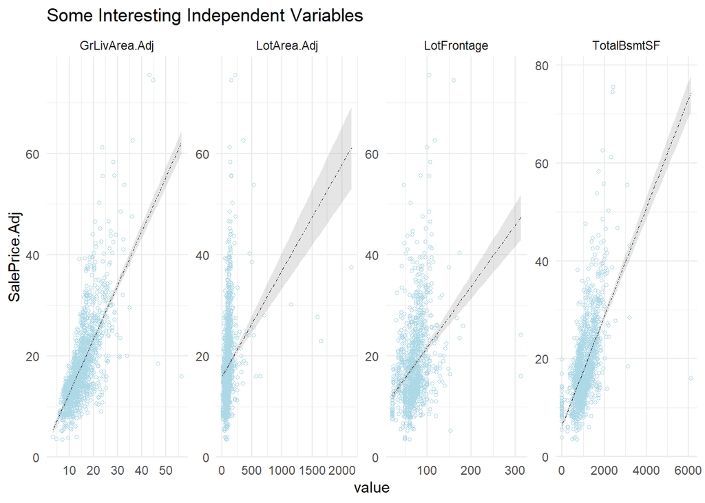

```r
# scatterplot matrix for at least two of the independent variables and the dependent variable
train  %>%
  mutate(SalePrice.Adj = SalePrice / 10000,
         GrLivArea.Adj = GrLivArea / 100,
         LotArea.Adj = LotArea / 100) %>%
  dplyr::select(SalePrice.Adj, LotArea.Adj, LotFrontage, GrLivArea.Adj, TotalBsmtSF) %>%
  gather(variable, value, -SalePrice.Adj) %>%
  ggplot(., aes(value, SalePrice.Adj)) +
  ggtitle("Some Interesting Independent Variables") +
  geom_point(fill = "white",
             size=1,
             shape=1,
             color="light blue") +
  geom_smooth(formula = y~x,
              method = "lm",
              size=.1,
              se = TRUE,
              color = "black",
              linetype = "dotdash",
              alpha=0.25) +
  facet_wrap(~variable,
             scales ="free",
             ncol = 4)
```

```r
  # theme(axis.text.x = element_blank(), axis.text.y = element_blank())
```

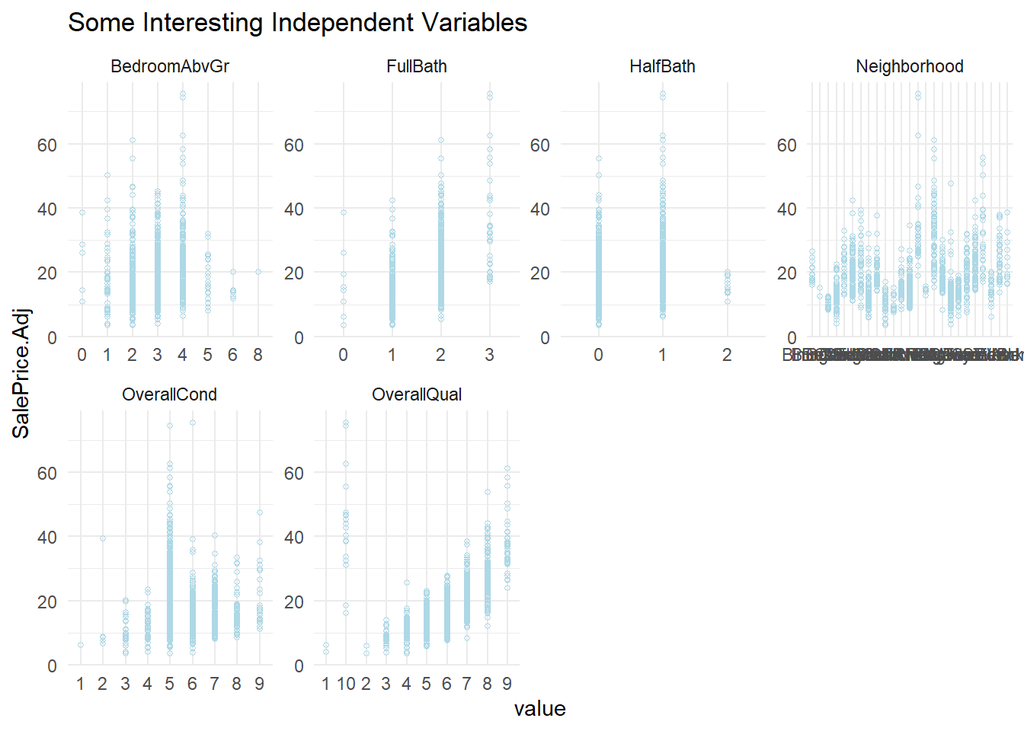

```r
train  %>%
  mutate(SalePrice.Adj = SalePrice / 10000) %>%
  dplyr::select(SalePrice.Adj, OverallQual, OverallCond, Neighborhood, BedroomAbvGr, FullBath, HalfBath) %>%
  gather(variable, value, -SalePrice.Adj) %>%
  ggplot(., aes(value, SalePrice.Adj)) +
  ggtitle("Some Interesting Independent Variables") +
  geom_point(fill = "white",
             size=1,
             shape=1,
             color="light blue") +
  geom_smooth(formula = y~x,
              method = "lm",
              size=.1,
              se = TRUE,
              color = "black",
              linetype = "dotdash",
              alpha=0.25) +
  facet_wrap(~variable,
             scales ="free",
             ncol = 4)
```

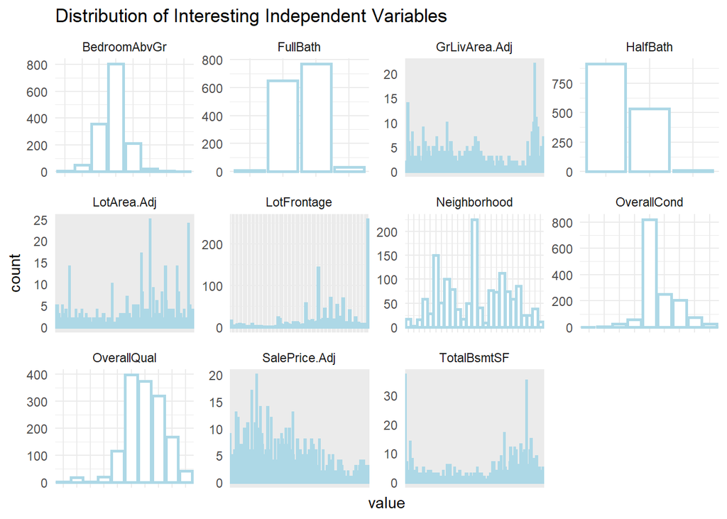

```r
train  %>%
  mutate(SalePrice.Adj = SalePrice / 10000,
         GrLivArea.Adj = GrLivArea / 100,
         LotArea.Adj = LotArea / 100) %>%
  dplyr::select(SalePrice.Adj, OverallQual, OverallCond, Neighborhood, BedroomAbvGr, FullBath, HalfBath,
         LotArea.Adj, LotFrontage, GrLivArea.Adj, TotalBsmtSF) %>%
  gather(variable, value) %>%
  ggplot(., aes(value)) +
  ggtitle("Distribution of Interesting Independent Variables") +
  geom_histogram(fill = "white",
             size=1,
             shape=1,
             color="light blue",
             stat = "count") +
  theme(axis.text.x = element_blank()) +
  facet_wrap(~variable,
             scales ="free",
             ncol = 4)
```

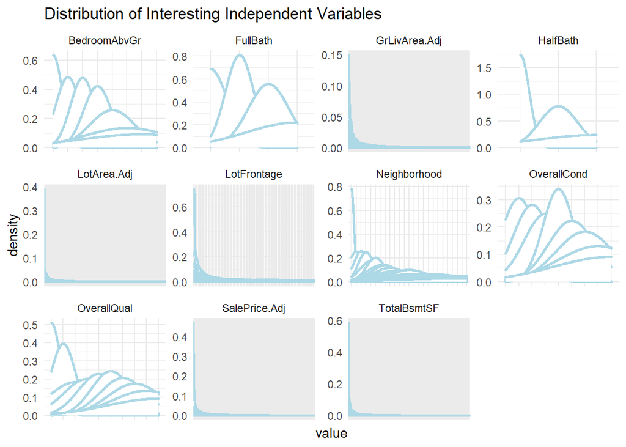

```r
train  %>%
  mutate(SalePrice.Adj = SalePrice / 10000,
         GrLivArea.Adj = GrLivArea / 100,
         LotArea.Adj = LotArea / 100) %>%
  dplyr::select(SalePrice.Adj, OverallQual, OverallCond, Neighborhood, BedroomAbvGr, FullBath, HalfBath,
         LotArea.Adj, LotFrontage, GrLivArea.Adj, TotalBsmtSF) %>%
  gather(variable, value) %>%
  ggplot(., aes(value)) +
  ggtitle("Distribution of Interesting Independent Variables") +
  geom_density(fill = "white",
             size=1,
             shape=1,
             color="light blue") +
  theme(axis.text.x = element_blank()) +
  facet_wrap(~variable,
             scales ="free",
             ncol = 4)
```

```r
# Derive a correlation matrix for any three quantitative variables
train %>%
  dplyr::select(SalePrice, LotArea, OverallQual, OverallCond) %>%
  cor() %>%
  as.matrix()
```

```
##               SalePrice     LotArea OverallQual OverallCond
## SalePrice    1.00000000  0.26384335  0.79098160 -0.07785589
## LotArea      0.26384335  1.00000000  0.10580574 -0.00563627
## OverallQual  0.79098160  0.10580574  1.00000000 -0.09193234
## OverallCond -0.07785589 -0.00563627 -0.09193234  1.00000000
```

```r
cor.test(train$SalePrice, train$OverallCond, conf.level = 0.80)
```

```
##
##  Pearson's product-moment correlation
##
## data:  train$SalePrice and train$OverallCond
## t = -2.9819, df = 1458, p-value = 0.002912
## alternative hypothesis: true correlation is not equal to 0
## 80 percent confidence interval:
##  -0.1111272 -0.0444103
## sample estimates:
##         cor
## -0.07785589
```

```r
cor.test(train$SalePrice, train$OverallQual, conf.level = 0.80)
```

```
##
##  Pearson's product-moment correlation
##
## data:  train$SalePrice and train$OverallQual
## t = 49.364, df = 1458, p-value < 2.2e-16
## alternative hypothesis: true correlation is not equal to 0
## 80 percent confidence interval:
##  0.7780752 0.8032204
## sample estimates:
##       cor
## 0.7909816
```

```r
cor.test(train$SalePrice, train$LotArea, conf.level = 0.80)
```

```
##
##  Pearson's product-moment correlation
##
## data:  train$SalePrice and train$LotArea
## t = 10.445, df = 1458, p-value < 2.2e-16
## alternative hypothesis: true correlation is not equal to 0
## 80 percent confidence interval:
##  0.2323391 0.2947946
## sample estimates:
##       cor
## 0.2638434
```

There should be no worries about familywise errors which is the probability of making a false discovery (in other words, type 1 errors) because the values are relatively intuitive and easily interpreted as right or wrong. For example, a false rejection of the null hypothesis in the case of LotArea would likely mean that we conclude that greater lot sizes did not have an effect on sale price when we know this to be false. We should expect that for almost any of these variables an increase in something considered good or valuable by most people would result in an increase in sales price.

Meanwhile our variables could use some help and it is doubtful that many are beneficial to use in predicting sales price. In some of the most interesting variables that we thought would have the most influence over sales price, many are right skewed heavily. This will cause the model to predict higher than observed values if not accounted for.

The three variables we expect to perform best are LotArea, OverallQual, and OverallCond. Their correlations are completely different. OverallQual had the strongest correlation with SalePrice at about 0.79 which makes sense given that most people would consider it important to think about the overall quality of the home before agreeing to purchase it. However, there is still plenty of room for misinterpretation in any of these variables.

### Section 2: Linear Algebra and Correlation

```r
cor.mtx <- train %>%
  dplyr::select(SalePrice, LotArea, OverallQual, OverallCond) %>%
  cor() %>%
  as.matrix()
pcn.mtx <- solve(cor.mtx)
rdu.mtx <- cor.mtx %*% pcn.mtx
lud.mtx <- lu.decomposition(rdu.mtx)
cor.mtx
```

```
##               SalePrice     LotArea OverallQual OverallCond
## SalePrice    1.00000000  0.26384335  0.79098160 -0.07785589
## LotArea      0.26384335  1.00000000  0.10580574 -0.00563627
## OverallQual  0.79098160  0.10580574  1.00000000 -0.09193234
## OverallCond -0.07785589 -0.00563627 -0.09193234  1.00000000
```

```r
pcn.mtx
```

```
##               SalePrice      LotArea OverallQual  OverallCond
## SalePrice    2.92833783 -0.533593316  -2.2582064  0.017378675
## LotArea     -0.53359332  1.108568702   0.3040949 -0.007339038
## OverallQual -2.25820645  0.304094866   2.7613570  0.079757301
## OverallCond  0.01737868 -0.007339038   0.0797573  1.008643943
```

```r
rdu.mtx
```

```
##                 SalePrice       LotArea   OverallQual   OverallCond
## SalePrice    1.000000e+00  2.287667e-17  8.673617e-19  0.000000e+00
## LotArea     -2.535678e-17  1.000000e+00 -6.342583e-18 -8.673617e-19
## OverallQual -1.084202e-16  1.821460e-17  1.000000e+00  0.000000e+00
## OverallCond -1.734723e-17 -6.938894e-18  4.163336e-17  1.000000e+00
```

```r
lud.mtx
```

```
## $L
##               [,1]          [,2]         [,3] [,4]
## [1,]  1.000000e+00  0.000000e+00 0.000000e+00    0
## [2,] -2.535678e-17  1.000000e+00 0.000000e+00    0
## [3,] -1.084202e-16  1.821460e-17 1.000000e+00    0
## [4,] -1.734723e-17 -6.938894e-18 4.163336e-17    1
##
## $U
##      [,1]         [,2]          [,3]          [,4]
## [1,]    1 2.287667e-17  8.673617e-19  0.000000e+00
## [2,]    0 1.000000e+00 -6.342583e-18 -8.673617e-19
## [3,]    0 0.000000e+00  1.000000e+00  1.579864e-35
## [4,]    0 0.000000e+00  0.000000e+00  1.000000e+00
```

### Section 3: Calculus-Based Probability & Statistics

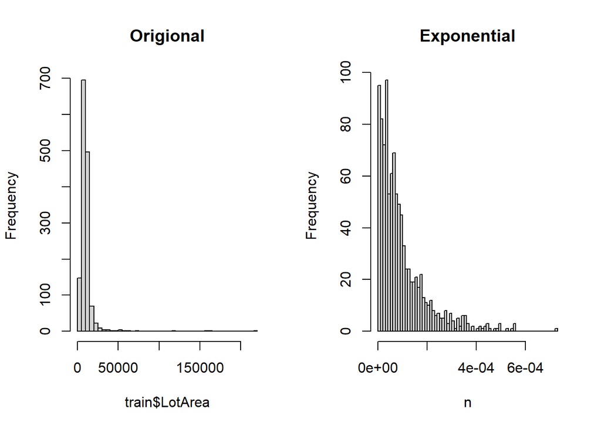

```r
fd.exp <- fitdistr(train$LotArea, densfun = "exponential")
y <- fd.exp$estimate
rate <- 1/y
n <- rexp(1000, rate)
par(mfrow = c(1,2))
hist(train$LotArea, breaks = 75, main = "Origional")
hist(n, breaks = 75, main = "Exponential")
```

```r
# 5th and 95th Percentiles
print(paste("CDF Percentile =", signif(qexp(c(0.05, 0.95), rate = rate), 3)))
```

```
## [1] "CDF Percentile = 4.88e-06" "CDF Percentile = 0.000285"
```

```r
# 95% confidence interval
print(paste("95% Confidence =",round((qnorm(c(0.025, 0.975),
      mean=mean(train$LotArea), sd=sd(train$LotArea))), 3)))
```

```
## [1] "95% Confidence = -9046.092" "95% Confidence = 30079.748"
```

```r
print(paste("Empirical =", round(quantile(train$LotArea, c(0.05, 0.95)), 3)))
```

```
## [1] "Empirical = 3311.7"   "Empirical = 17401.15"
```

### Section 4: Modeling

```r
mod1 <- lm(SalePrice~LotArea + OverallQual, train)
summary(mod1)
```

```
##
## Call:
## lm(formula = SalePrice ~ LotArea + OverallQual, data = train)
##
## Residuals:
##     Min      1Q  Median      3Q     Max
## -271225  -26819   -1459   20172  385190
##
## Coefficients:
##               Estimate Std. Error t value Pr(>|t|)
## (Intercept) -1.047e+05  5.547e+03  -18.88   <2e-16 ***
## LotArea      1.450e+00  1.225e-01   11.83   <2e-16 ***
## OverallQual  4.433e+04  8.844e+02   50.12   <2e-16 ***
## ---
## Signif. codes:  0 '***' 0.001 '**' 0.01 '*' 0.05 '.' 0.1 ' ' 1
##
## Residual standard error: 46460 on 1457 degrees of freedom
## Multiple R-squared:  0.6585, Adjusted R-squared:  0.658
## F-statistic:  1405 on 2 and 1457 DF,  p-value: < 2.2e-16
```

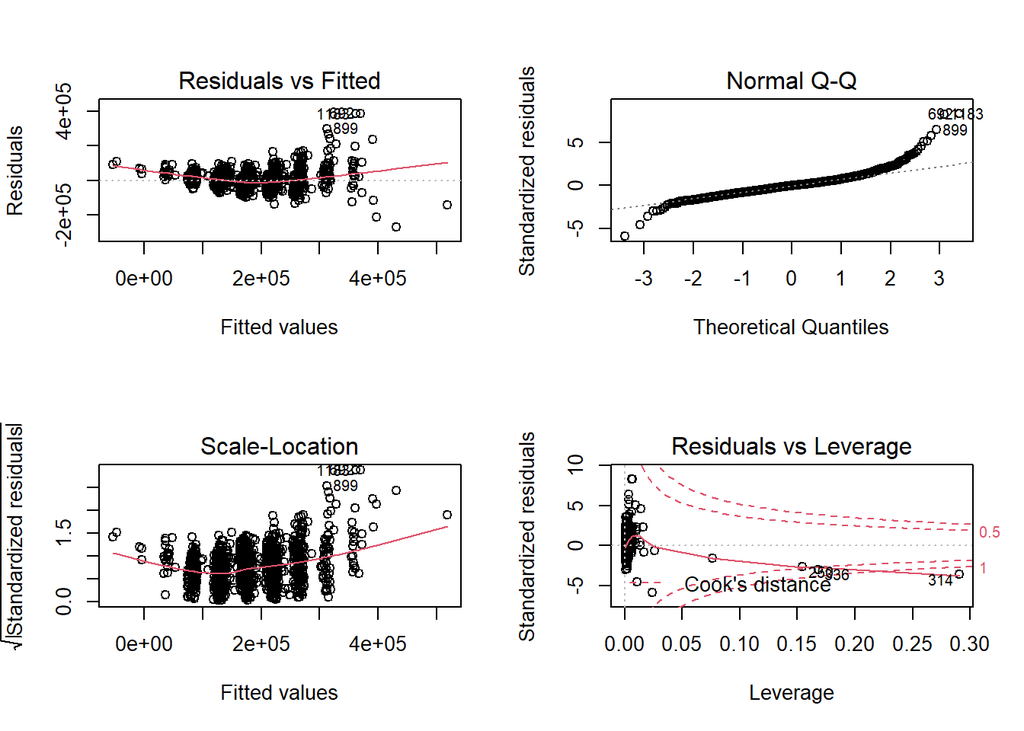

```r
par(mfrow = c(2,2))
plot(mod1)
```

```r
mod2.lm <- lm(SalePrice ~ LotArea +
                Neighborhood +
                LotFrontage +
                OverallQual +
                OverallCond +
                GrLivArea +
                HalfBath +
                FullBath +
                TotRmsAbvGrd +
                TotalBsmtSF +
                YearRemodAdd +
                YearBuilt +
                Fireplaces +
                GarageFinish +
                PavedDrive +
                GarageArea +
                GarageYrBlt +
                GarageCars +
                PoolArea +
                KitchenAbvGr +
                KitchenQual +
                SaleCondition +
                SaleType +
                factor(OverallQual) +
                LandSlope +
                rexp(LotArea) +
                rexp(LotFrontage) +
                rexp(GrLivArea) +
                rexp(TotRmsAbvGrd) +
                rexp(TotalBsmtSF) +
                rexp(GarageArea)
              , train)
mod2.both <- stepAIC(mod2.lm, trace = F, direction = "both")
mod2.call <- summary(mod2.both)$call
mod2 <- lm(mod2.call[2], train)
summary(mod2)
```

```
##
## Call:
## lm(formula = mod2.call[2], data = train)
##
## Residuals:
##     Min      1Q  Median      3Q     Max
## -393429  -12267    -636   10598  238004
##
## Coefficients:
##                         Estimate Std. Error t value Pr(>|t|)
## (Intercept)           -4.709e+05  2.225e+05  -2.117 0.034530 *
## LotArea                7.709e-01  1.585e-01   4.864 1.32e-06 ***
## NeighborhoodBlueste   -1.355e+04  2.492e+04  -0.544 0.586707
## NeighborhoodBrDale    -7.978e+02  1.323e+04  -0.060 0.951921
## NeighborhoodBrkSide    1.483e+04  1.171e+04   1.267 0.205491
## NeighborhoodClearCr    2.964e+04  1.372e+04   2.160 0.031006 *
## NeighborhoodCollgCr    2.517e+04  9.649e+03   2.609 0.009221 **
## NeighborhoodCrawfor    3.690e+04  1.150e+04   3.210 0.001366 **
## NeighborhoodEdwards   -5.310e+03  1.059e+04  -0.502 0.615997
## NeighborhoodGilbert    1.195e+04  1.033e+04   1.157 0.247640
## NeighborhoodIDOTRR     1.430e+03  1.253e+04   0.114 0.909138
## NeighborhoodMeadowV   -8.362e+03  1.429e+04  -0.585 0.558630
## NeighborhoodMitchel    1.885e+04  1.116e+04   1.690 0.091391 .
## NeighborhoodNAmes      1.583e+04  1.026e+04   1.542 0.123390
## NeighborhoodNoRidge    7.785e+04  1.127e+04   6.909 8.44e-12 ***
## NeighborhoodNPkVill    8.952e+02  1.581e+04   0.057 0.954861
## NeighborhoodNridgHt    4.630e+04  1.019e+04   4.543 6.17e-06 ***
## NeighborhoodNWAmes     1.240e+04  1.077e+04   1.151 0.249932
## NeighborhoodOldTown    4.527e+03  1.129e+04   0.401 0.688593
## NeighborhoodSawyer     1.382e+04  1.096e+04   1.261 0.207736
## NeighborhoodSawyerW    2.367e+04  1.051e+04   2.252 0.024505 *
## NeighborhoodSomerst    2.739e+04  9.918e+03   2.762 0.005848 **
## NeighborhoodStoneBr    6.889e+04  1.181e+04   5.834 7.19e-09 ***
## NeighborhoodSWISU      4.196e+03  1.320e+04   0.318 0.750622
## NeighborhoodTimber     2.584e+04  1.098e+04   2.354 0.018740 *
## NeighborhoodVeenker    4.400e+04  1.564e+04   2.814 0.004985 **
## LotFrontage           -1.206e+02  5.472e+01  -2.204 0.027729 *
## OverallCond            7.554e+03  1.241e+03   6.085 1.63e-09 ***
## GrLivArea              3.687e+01  5.250e+00   7.023 3.87e-12 ***
## HalfBath               1.307e+02  2.759e+03   0.047 0.962237
```

[output cut: 31 more lines]

```
## LandSlopeMod           1.320e+04  5.332e+03   2.476 0.013447 *
## LandSlopeSev          -2.185e+04  1.712e+04  -1.277 0.202047
## rexp(LotArea)         -6.386e+02  9.900e+02  -0.645 0.519025
## rexp(LotFrontage)      1.267e+02  1.066e+03   0.119 0.905379
## rexp(GrLivArea)        7.868e+02  9.221e+02   0.853 0.393733
## rexp(TotRmsAbvGrd)    -3.576e+02  1.025e+03  -0.349 0.727288
## rexp(TotalBsmtSF)      2.712e+02  9.621e+02   0.282 0.778076
## rexp(GarageArea)      -8.183e+02  9.876e+02  -0.829 0.407503
## ---
## Signif. codes:  0 '***' 0.001 '**' 0.01 '*' 0.05 '.' 0.1 ' ' 1
##
## Residual standard error: 32160 on 1058 degrees of freedom
##   (333 observations deleted due to missingness)
## Multiple R-squared:  0.8597, Adjusted R-squared:  0.8507
## F-statistic: 95.32 on 68 and 1058 DF,  p-value: < 2.2e-16
```

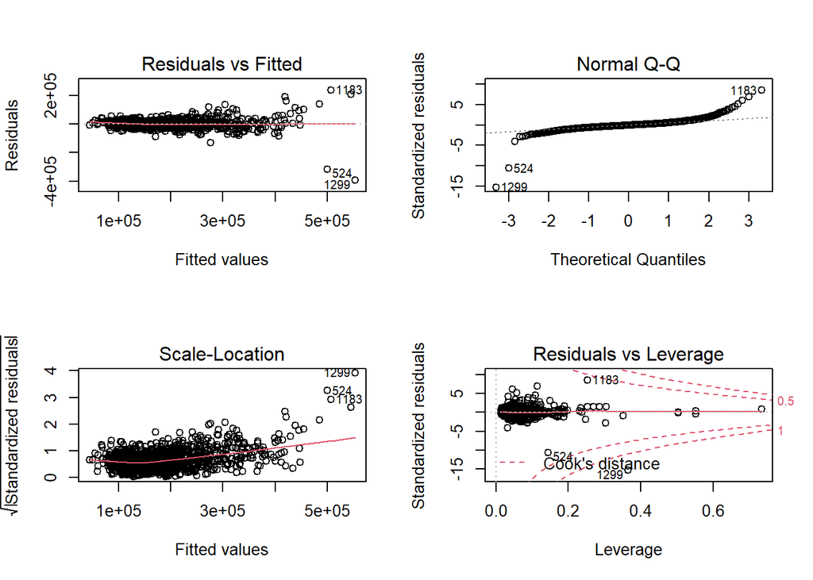

```r
par(mfrow=c(2,2))
plot(mod2)
```

The goal in this model was to add any variables to the plot we thougth might influence the sales price at then see if there any new trends we to be noticed and there are. Our initial expectation is at least partially wrong. We missed out on several beneficial variables (and may have missed more than what is listed here). Many of these predictors are not significant or particularly useful in predicting sales price. We select those that are significant and clean them up a bit before creating our third model.

```r
train$LotFrontage[is.na(train$LotFrontage)] <- median(train$LotFrontage, na.rm = T)
train$GarageCars[is.na(train$GarageCars)] <- median(train$GarageCars, na.rm = T)
train$TotalBsmtSF[is.na(train$TotalBsmtSF)] <- median(train$TotalBsmtSF, na.rm = T)
train$SaleType[is.na(train$SaleType)] <- "WD"
train$KitchenQual[is.na(train$KitchenQual)] <- "TA"
train$GarageFinish[is.na(train$GarageFinish)] <- "Unf"
mod3 <- lm(SalePrice ~
             LandSlope +
             OverallQual +
             KitchenQual +
             KitchenAbvGr +
             GarageCars +
             GarageFinish +
             Fireplaces +
             YearBuilt +
             TotalBsmtSF +
             TotRmsAbvGrd +
             SaleType +
             GrLivArea +
             OverallCond +
             LotFrontage +
             Neighborhood
             , train)
summary(mod3)
```

```
##
## Call:
## lm(formula = SalePrice ~ LandSlope + OverallQual + KitchenQual +
##     KitchenAbvGr + GarageCars + GarageFinish + Fireplaces + YearBuilt +
##     TotalBsmtSF + TotRmsAbvGrd + SaleType + GrLivArea + OverallCond +
##     LotFrontage + Neighborhood, data = train)
##
## Residuals:
##     Min      1Q  Median      3Q     Max
## -409980  -13199    -946   12369  246545
##
## Coefficients:
##                       Estimate Std. Error t value Pr(>|t|)
## (Intercept)         -5.372e+05  1.380e+05  -3.892 0.000104 ***
## LandSlopeMod         1.626e+04  4.290e+03   3.791 0.000156 ***
## LandSlopeSev         1.931e+04  9.839e+03   1.962 0.049901 *
## OverallQual          9.877e+03  1.172e+03   8.427  < 2e-16 ***
## KitchenQualFa       -3.897e+04  7.299e+03  -5.339 1.09e-07 ***
## KitchenQualGd       -4.035e+04  4.084e+03  -9.882  < 2e-16 ***
## KitchenQualTA       -4.194e+04  4.629e+03  -9.061  < 2e-16 ***
## KitchenAbvGr        -1.904e+04  4.372e+03  -4.355 1.43e-05 ***
## GarageCars           1.180e+04  1.610e+03   7.331 3.84e-13 ***
## GarageFinishRFn     -8.140e+03  2.536e+03  -3.210 0.001357 **
## GarageFinishUnf     -8.356e+03  2.900e+03  -2.881 0.004025 **
## Fireplaces           7.057e+03  1.639e+03   4.305 1.79e-05 ***
## YearBuilt            2.679e+02  6.868e+01   3.901 0.000100 ***
## TotalBsmtSF          2.026e+01  2.630e+00   7.705 2.45e-14 ***
## TotRmsAbvGrd         2.260e+03  1.017e+03   2.223 0.026395 *
## SaleTypeCon          5.040e+04  2.374e+04   2.123 0.033925 *
## SaleTypeConLD        1.334e+04  1.183e+04   1.127 0.259838
## SaleTypeConLI        1.377e+04  1.522e+04   0.905 0.365826
## SaleTypeConLw        7.228e+03  1.526e+04   0.474 0.635804
## SaleTypeCWD          2.118e+04  1.683e+04   1.258 0.208436
## SaleTypeNew          2.487e+04  6.137e+03   4.052 5.35e-05 ***
## SaleTypeOth          3.214e+04  1.929e+04   1.666 0.095950 .
## SaleTypeWD           7.640e+03  5.080e+03   1.504 0.132830
## GrLivArea            4.078e+01  3.708e+00  10.998  < 2e-16 ***
## OverallCond          7.086e+03  8.971e+02   7.899 5.64e-15 ***
## LotFrontage         -1.423e+01  4.676e+01  -0.304 0.761018
## NeighborhoodBlueste -1.293e+04  2.418e+04  -0.535 0.592839
```

[output cut: 14 more lines]

```
## NeighborhoodNWAmes   1.181e+04  9.124e+03   1.294 0.195952
## NeighborhoodOldTown  4.089e+03  9.821e+03   0.416 0.677250
## NeighborhoodSawyer   1.678e+04  9.319e+03   1.800 0.072040 .
## NeighborhoodSawyerW  2.466e+04  9.134e+03   2.700 0.007023 **
## NeighborhoodSomerst  3.103e+04  8.715e+03   3.561 0.000382 ***
## NeighborhoodStoneBr  7.270e+04  1.023e+04   7.109 1.85e-12 ***
## NeighborhoodSWISU    6.797e+03  1.131e+04   0.601 0.548045
## NeighborhoodTimber   3.456e+04  9.495e+03   3.640 0.000282 ***
## NeighborhoodVeenker  4.499e+04  1.280e+04   3.516 0.000452 ***
## ---
## Signif. codes:  0 '***' 0.001 '**' 0.01 '*' 0.05 '.' 0.1 ' ' 1
##
## Residual standard error: 31820 on 1410 degrees of freedom
## Multiple R-squared:  0.845,  Adjusted R-squared:  0.8396
## F-statistic: 156.8 on 49 and 1410 DF,  p-value: < 2.2e-16
```

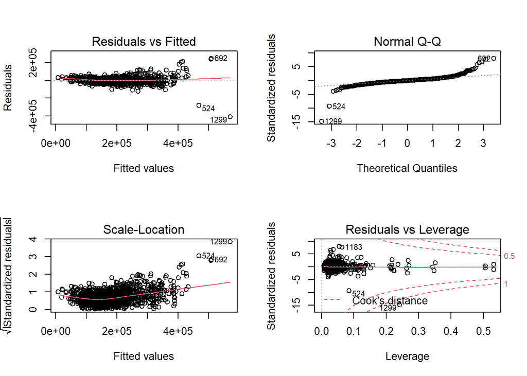

```r
par(mfrow = c(2,2))
plot(mod3)
```

```r
# Make predictions
df <- test %>%
  dplyr::select(
            LandSlope,
             OverallQual,
             KitchenQual,
             KitchenAbvGr,
             GarageCars,
             GarageFinish,
             Fireplaces,
             YearBuilt,
             TotalBsmtSF,
             TotRmsAbvGrd,
             SaleType,
             GrLivArea,
             OverallCond,
             LotFrontage,
             Neighborhood)
# impute missing values
df$LotFrontage[is.na(df$LotFrontage)] <- median(df$LotFrontage, na.rm = T)
df$GarageCars[is.na(df$GarageCars)] <- median(df$GarageCars, na.rm = T)
df$TotalBsmtSF[is.na(df$TotalBsmtSF)] <- median(df$TotalBsmtSF, na.rm = T)
df[df=='NA'] <- NA
df$SaleType[is.na(df$SaleType)] <- "WD"
df$KitchenQual[is.na(df$KitchenQual)] <- "TA"
df$GarageFinish[is.na(df$GarageFinish)] <- "Unf"
predictions <- data.frame(test$Id, predict(mod3, df))
colnames(predictions) <- c("Id","SalePrice")
```

```r
# Export to csv for kaggle submission
write.csv(predictions, "C:/data/predictions.csv")
```

My Kaggle username is “zacharypalmore” and my score is 0.17215. This could have been greatly improved if I had imputed with realistic values removed missing values prior to each model, considered other variables beyond these initial thoughts, and much more. Honestly, I am surprised it turned out as well as it did given the circumstances.